# Abdulrahman Hamad Al Duayj

# Multivariate Analysis

### Were there any interesting or surprising interactions between features?

Yes, some relationship that have high correlation coefficient do not have insight like the relationship between " fixed acidity va density" and " fixed acidity va PH“.

# Final Plots and Summary

### Plot One

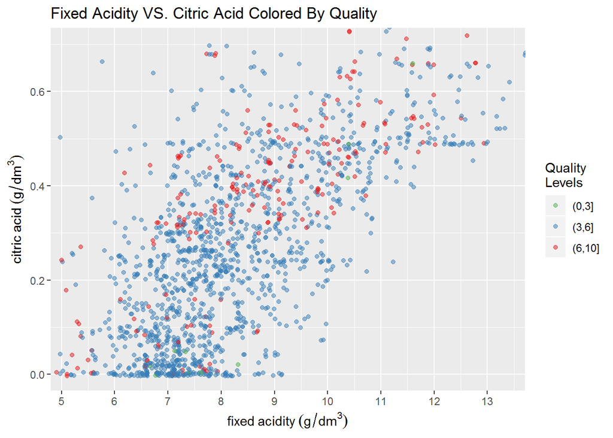

### Description One

The above plot has positive relationship, We can see that the good red wine quality has higher citric acid and higher fixed acidity.

### Plot Two

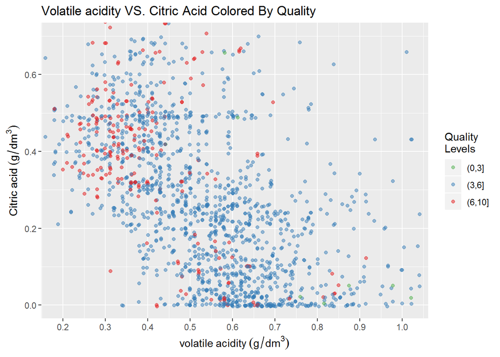

### Description Two

The above plot has negative relationship, when citric acid decreases and volatile acidity increases the quality of red wine will decrease.

### Plot Three

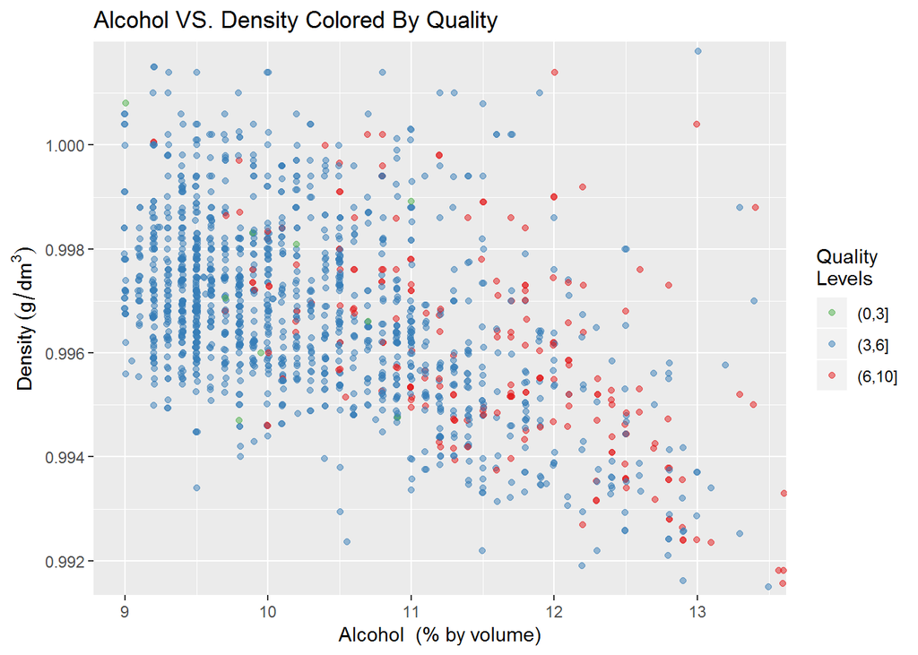

### Description Three

The above plot has negative relationship, Decrease of density and increase of alcohol leads to have high red wine quality.

# Reflection

Our study about the quality of red wine, our data set has 1599 of red wine samples and 12 Attribute informations. First i starting reading the test file attached which describes the variables and how the data was collected in order to understand the variables and the data. I wished if there was specific categorical for the alcohol volume (standard text levels) beside the numeric volume Instead of guessing it ourselves.

The red wine quality study is a complex study, what is surprising that some relationship between variables have high correlation coefficient and has no insights or special impact for the red wine quality.

Finally, There is no specific factor that determine the quality of the red wine, Actually the quality of red wine determined by several factors generally increase alcohol volume, reduce density, reduce volatile acidity and increase citric acid.

The end Of report, Thank you.